# chap4_keras.R

hahsler

2020-06-20

This code covers chapter 4 of *“Introduction to Data Mining”* by Pang-Ning Tan, Michael Steinbach and Vipin Kumar. **See [table of contents](https://github.com/mhahsler/Introduction_to_Data_Mining_R_Examples#readme) for code examples for other chapters.**

This work is licensed under the [Creative Commons Attribution 4.0 International License](http://creativecommons.org/licenses/by/4.0/). For questions please contact [Michael Hahsler](http://michael.hahsler.net).

Show fewer digits

```r
options(digits=3)
```

# Install keras and tensorflow

R> install.packages(“keras”)

R> library(keras)

R> install_tensorflow()

R> install_keras()

```r
library(keras)
library(tidyverse)
```

# Load and prepare the data set

```r
data(Zoo, package = "mlbench")
Zoo <- as_tibble(Zoo)
Zoo
```

```
## # A tibble: 101 x 17
##    hair  feathers eggs  milk  airborne aquatic predator toothed backbone
##    <lgl> <lgl>    <lgl> <lgl> <lgl>    <lgl>   <lgl>    <lgl>   <lgl>
##  1 TRUE  FALSE    FALSE TRUE  FALSE    FALSE   TRUE     TRUE    TRUE
##  2 TRUE  FALSE    FALSE TRUE  FALSE    FALSE   FALSE    TRUE    TRUE
##  3 FALSE FALSE    TRUE  FALSE FALSE    TRUE    TRUE     TRUE    TRUE
##  4 TRUE  FALSE    FALSE TRUE  FALSE    FALSE   TRUE     TRUE    TRUE
##  5 TRUE  FALSE    FALSE TRUE  FALSE    FALSE   TRUE     TRUE    TRUE
##  6 TRUE  FALSE    FALSE TRUE  FALSE    FALSE   FALSE    TRUE    TRUE
##  7 TRUE  FALSE    FALSE TRUE  FALSE    FALSE   FALSE    TRUE    TRUE
##  8 FALSE FALSE    TRUE  FALSE FALSE    TRUE    FALSE    TRUE    TRUE
##  9 FALSE FALSE    TRUE  FALSE FALSE    TRUE    TRUE     TRUE    TRUE
## 10 TRUE  FALSE    FALSE TRUE  FALSE    FALSE   FALSE    TRUE    TRUE
## # … with 91 more rows, and 8 more variables: breathes <lgl>, venomous <lgl>,
## #   fins <lgl>, legs <int>, tail <lgl>, domestic <lgl>, catsize <lgl>,
## #   type <fct>
```

```r
Zoo_predictors <- Zoo %>% select(-type)
Zoo_class <- Zoo %>% pull(type)
```

Create a matrix and normalize the data (using kera’s `normalize()` function). If you have nominal variables (factor), then you need to use kera’s `to_categorical()` function to create one-hot encoding.

```r
Zoo_predictors <- Zoo_predictors %>% as.matrix() %>% normalize()
head(Zoo_predictors)
```

```
##       [,1] [,2]  [,3]  [,4] [,5]  [,6]  [,7]  [,8]  [,9] [,10] [,11] [,12]
## [1,] 0.209    0 0.000 0.209    0 0.000 0.209 0.209 0.209 0.209     0 0.000
## [2,] 0.209    0 0.000 0.209    0 0.000 0.000 0.209 0.209 0.209     0 0.000
## [3,] 0.000    0 0.378 0.000    0 0.378 0.378 0.378 0.378 0.000     0 0.378
## [4,] 0.209    0 0.000 0.209    0 0.000 0.209 0.209 0.209 0.209     0 0.000
## [5,] 0.204    0 0.000 0.204    0 0.000 0.204 0.204 0.204 0.204     0 0.000
## [6,] 0.209    0 0.000 0.209    0 0.000 0.000 0.209 0.209 0.209     0 0.000
##      [,13] [,14] [,15] [,16]
## [1,] 0.834 0.000     0 0.209
## [2,] 0.834 0.209     0 0.209
## [3,] 0.000 0.378     0 0.000
## [4,] 0.834 0.000     0 0.209
## [5,] 0.816 0.204     0 0.204
## [6,] 0.834 0.209     0 0.209
```

One-hot encode the class variable

**Note:** needs an integer with the first class being 0 and not 1

```r
Zoo_class <- to_categorical(as.integer(Zoo_class) - 1L)
head(Zoo_class)
```

```
##      [,1] [,2] [,3] [,4] [,5] [,6] [,7]
## [1,]    1    0    0    0    0    0    0
## [2,]    1    0    0    0    0    0    0
## [3,]    0    0    0    1    0    0    0
## [4,]    1    0    0    0    0    0    0
## [5,]    1    0    0    0    0    0    0
## [6,]    1    0    0    0    0    0    0
```

# Construct the model structure

```r
model <- keras_model_sequential()

model %>%
  layer_dense(units = 16, activation = 'relu', input_shape = c(ncol(Zoo_predictors)),
    kernel_regularizer=regularizer_l2(l = 0.001)) %>%
  layer_dropout(.1) %>%
  layer_dense(units = 8, activation = 'relu',
    kernel_regularizer=regularizer_l2(l = 0.001)) %>%
  layer_dense(units = ncol(Zoo_class), activation = 'softmax')
model
```

```
## Model
## Model: "sequential"
## ________________________________________________________________________________
## Layer (type)                        Output Shape                    Param #
## ================================================================================
## dense (Dense)                       (None, 16)                      272
## ________________________________________________________________________________
## dropout (Dropout)                   (None, 16)                      0
## ________________________________________________________________________________
## dense_1 (Dense)                     (None, 8)                       136
## ________________________________________________________________________________
## dense_2 (Dense)                     (None, 7)                       63
## ================================================================================
## Total params: 471
## Trainable params: 471
## Non-trainable params: 0
## ________________________________________________________________________________
```

See `? layer_dense` to learn more about creating the model structure

Compile the model

```r
model %>% compile(
  loss = 'categorical_crossentropy',
  optimizer = 'adam',
  metrics = 'accuracy'
)
```

*Note:* Choices are the activation function, number of layers, number of units per layer and the optimizer. A dropout layer and L2 regularizer is used for the dense layer weights to reduce overfitting. The output is a categorical class value, therefore the output layer uses the softmax activation function, the loss is categorical crossentropy, and the metric is accuracy.

# Fit the model

Uses 20% of the data for validation

```r
train <- sample(c(TRUE, FALSE), size = nrow(Zoo), prob = c(0.8, 0.2), replace = TRUE)

history <- model %>% fit(
  Zoo_predictors[train,],
  Zoo_class[train,],
  validation_data = list(Zoo_predictors[!train, ], Zoo_class[!train, ]),
  epochs = 200,
  batch_size = 2^3
)

history
```

```
##
## Final epoch (plot to see history):
##         loss: 0.2211
##     accuracy: 0.9189
##     val_loss: 0.3592
## val_accuracy: 0.9259
```

`val_acc` is the accuracy on the test (validation) set.

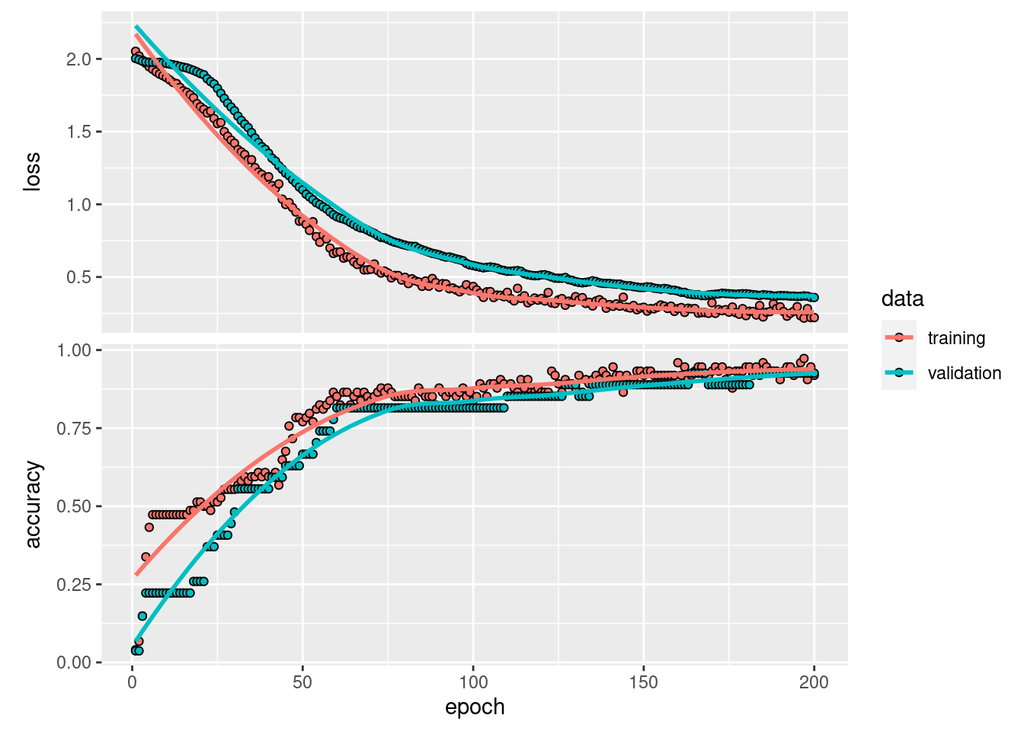

```r
plot(history)
```

# Make predictions on the test set

**Note:** classes starts with index 0 not 1

```r
classes <- model %>% predict_classes(Zoo_predictors[!train,], batch_size = 2^7)

library(caret)
confusionMatrix(
  data = factor(classes+1L, levels = 1:length(levels(Zoo$type)), labels = levels(Zoo$type)),
  ref = Zoo$type[!train]
  )
```

```
## Confusion Matrix and Statistics
##
##                Reference
## Prediction      mammal bird reptile fish amphibian insect mollusc.et.al
##   mammal             6    0       0    0         0      0             0
##   bird               0   10       0    0         0      0             0
##   reptile            0    0       1    0         0      0             0
##   fish               0    0       1    1         0      0             0
##   amphibian          0    0       1    0         1      0             0
##   insect             0    0       0    0         0      3             0
##   mollusc.et.al      0    0       0    0         0      0             3
##
## Overall Statistics
##
##                Accuracy : 0.926
##                  95% CI : (0.757, 0.991)
##     No Information Rate : 0.37
##     P-Value [Acc > NIR] : 2.39e-09
##
##                   Kappa : 0.905
##
##  Mcnemar's Test P-Value : NA
##
## Statistics by Class:
##
##                      Class: mammal Class: bird Class: reptile Class: fish
## Sensitivity                  1.000        1.00          0.333      1.0000
## Specificity                  1.000        1.00          1.000      0.9615
## Pos Pred Value               1.000        1.00          1.000      0.5000
## Neg Pred Value               1.000        1.00          0.923      1.0000
## Prevalence                   0.222        0.37          0.111      0.0370
## Detection Rate               0.222        0.37          0.037      0.0370
## Detection Prevalence         0.222        0.37          0.037      0.0741
## Balanced Accuracy            1.000        1.00          0.667      0.9808
##                      Class: amphibian Class: insect Class: mollusc.et.al
## Sensitivity                    1.0000         1.000                1.000
## Specificity                    0.9615         1.000                1.000
## Pos Pred Value                 0.5000         1.000                1.000
## Neg Pred Value                 1.0000         1.000                1.000
## Prevalence                     0.0370         0.111                0.111
## Detection Rate                 0.0370         0.111                0.111
## Detection Prevalence           0.0741         0.111                0.111
## Balanced Accuracy              0.9808         1.000                1.000
```